# Is There an Association Between Religion and Income

October 19 2014

### Introduction:

Religious affiliation is still common in the United States. As we can see from the output below only 11% of Americans list None as their religion. This analysis will consider the interesting issue of religion and household income. We look at the following question. **Are religious affiliation and personal income are associated?**

```r
prop.table(sort(table(gss$relig),decreasing=TRUE))*100
```

```
##
##              Protestant                Catholic                    None
##                58.90054                24.50553                10.75702
##                  Jewish                   Other               Christian
##                 2.03245                 1.75618                 1.03470
##                Buddhism Inter-Nondenominational            Moslem/Islam
##                 0.22876                 0.21820                 0.19005
##      Orthodox-Christian                Hinduism           Other Eastern
##                 0.16893                 0.11086                 0.05455
##         Native American
##                 0.04223
```

### Data:

The data for this analysis was collected from the General Social Survey [1]. The data set includes 57061 observations. The data set was reduced to the five most common religious affiliation which are Protestant, Catholic, Jewish, None, and Other. We limited the data to these five in order to make the analysis more concise and easier to interpret. The two variables used from the GSS data set are relig, a categorical variable indicating a respondent’s religious affiliation, and the coninc variable, a numerical variable for the respondents income. The coninc variable is adjusted for inflation so we can use the data for every year of the study. The GSS is an observational study. We can only use the GSS data for generalizing the analysis for the population and not for claims of causality because the data is the result of an observational study.

### Exploratory data analysis:

The exploratory analysis below shows the possible association of religious affiliation and income. Especially interesting is **Figure 2** which shows one religion, Judaism(Jewish), leading the others in terms of income.

```r
# get rid of rows with NA for coninc
gss <- gss[!is.na(gss$coninc),]
gss <- gss[!is.na(gss$relig),c("relig","coninc")]
gss <- gss[gss$relig %in% c("Protestant","Catholic","Other","Jewish","None"),]
gss$relig <- factor(gss$relig)
# get income statistics by religion
stats <- ddply(gss, .(relig),summarise,
                 relig.count = length(relig),
                 relig.mean= mean(coninc),
                 relig.median = median(coninc),
                 relig.max = max(coninc),
                 relig.sd = sd(coninc)
                 )
options(width=120)
```

**Summary Statistics:**

```r
print(stats[order(stats$relig.mean,decreasing=TRUE),],row.names = FALSE)
```

```
##       relig relig.count relig.mean relig.median relig.max relig.sd
##      Jewish         965      68765        56836    180386    47081
##    Catholic       12488      47623        38960    180386    36413
##        None        5527      46336        35471    180386    39794
##       Other         910      44396        35471    178266    35257
##  Protestant       30187      42004        33931    180386    33951
```

**Exploratory Plots:**

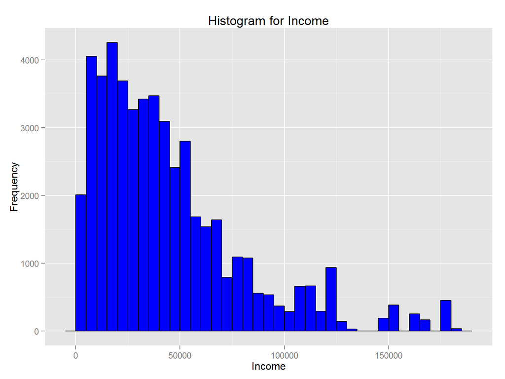

```r
g <- ggplot(data=gss,aes(x=coninc)) +
     geom_histogram(binwidth=5000,color="black",fill="blue") +
     xlab("Income") + ylab("Frequency") + ggtitle("Histogram for Income")
g
```

**Figure 1** is a histogram showing the income variable as one would expect the distribution is right skewed because a few high income earners. This skewness is expected given the income inequality present in the United States.

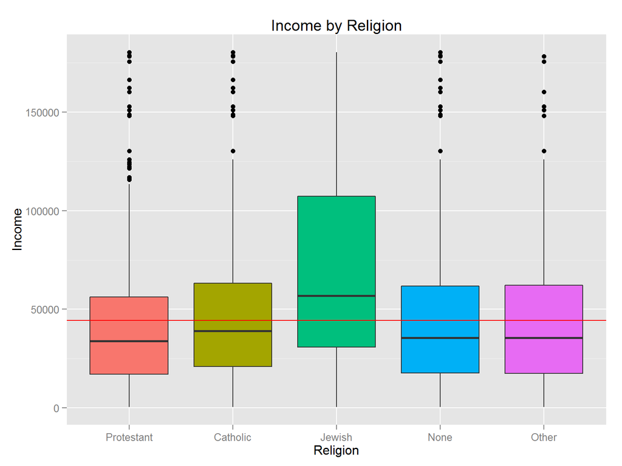

```r
m <- mean(gss$coninc)
g <- ggplot(data=gss,aes(x=relig,y=coninc)) + geom_boxplot(aes(fill=factor(relig))) +
           xlab("Religion") + ylab("Income") +
           theme(legend.position = "none") +
           geom_hline(y=m,color="red") + ggtitle("Income by Religion")
g
```

**Figure 2** is boxplot showing income differences by religion. One religion, Judaism, clearly outpaces the others in terms of income.

### Inference:

The Analysis of Variance Analysis (ANOVA) output below confirms the exploratory analysis that shows a disparity between income for the religious groups. The null hypothesis is that there is no difference in average income among the religious groups. The ANOVA output below returns the F statistic of 177.1 which has a p value very close to 0. This extremely low p value indicates that we should reject the null hypothesis.

**Conditions for ANOVA Analysis** The three conditions needed for a successful ANOVA are independence, approximate normality, and constant variance [2]. The condition of independence is easily met since sample is random and much less than 10 percent of the population of the United States. The normality condition is not as clear cut since the data is right skewed. The number relative high number of samples allows us to pass this condition.

**ANOVA Output**

```r
fit <- aov(gss$coninc ~ gss$relig)
summary(fit)
```

```
##                Df   Sum Sq  Mean Sq F value Pr(>F)
## gss$relig       4 8.96e+11 2.24e+11     177 <2e-16 ***
## Residuals   50072 6.34e+13 1.27e+09
## ---
## Signif. codes:  0 '***' 0.001 '**' 0.01 '*' 0.05 '.' 0.1 ' ' 1
```

```r
coefficients(fit)
```

```
##       (Intercept) gss$religCatholic   gss$religJewish     gss$religNone    gss$religOther
##             42004              5619             26760              4332              2392
```

### Conclusion:

While the GSS is an observational study and we cannot make a claim of causation that someone’s religion determines helps determine their income, we can state there seems to be some association between religion and income.

### References:

1. Smith, Tom W., Michael Hout, and Peter V. Marsden. General Social Survey, 1972-2012 [Cumulative File]. ICPSR34802-v1. Storrs, CT: Roper Center for Public Opinion Research, University of Connecticut /Ann Arbor, MI: Inter-university Consortium for Political and Social Research [distributors], 2013-09-11. doi:10.3886/ICPSR34802.v1 Persistent URL: http://doi.org/10.3886/ICPSR34802.v1
2. Diez, David, Christopher Barr, and Mine Cetinkaya-Rundel. Openintro Statistics. 2012.